# A barrier model illustration

Elias T Krainski

2023, March

# Abstract

In this tutorial we illustrate a new implementation of the model proposed in Bakka et al. (2019). It consider the problem of modeling over a spatial domain accounting for physical barriers. The original implementation is illustrated in [this tutorial](https://haakonbakkagit.github.io/btopic128.html). The re-implementation consider a new (faster) computational method available in the **INLA** package.

# Introduction

Suppose that there is a phenomena that varies over a spatial domain. Models usually consider correlation between observations made. Considering a pair of observations, the correlation is usually specified as a function of the distance between the location sites from where these observations were collected. If there is a barrier in the spatial domain, this correlation for a pair of observations taken from sites in different sides of the barrier shall consider the barrier. In resume, it should no longer be just a function of the distance. Basically, the correlation between points in two different sides of the barrier should decay faster (than the usual) to zero and “does not cross the domain”.

In order to illustrate the problem, let us define a rectangle as our spatial domain:

```r
rxy <- c(10, 7)
r <- mean(rxy)
bb <- rbind(
    c(0, 1)*rxy[1],
    c(0, 1)*rxy[2])
domain <- cbind(
    c(0, 1, 1, 0, 0) * rxy[1],
    c(0, 0, 1, 1, 0) * rxy[2])
```

We will now set the barrier as the two polygons defined as follows

```r
barrier1 <- cbind(
  cos(seq(0, 2*pi, length=50)) * 0.7 + 0.50 * rxy[1],
  sin(seq(0, 2*pi, length=50)) * 1.2 + 0.75 * rxy[2])
barrier2 <- cbind(
  c(0.50, 1.50, 1.50, 0.50, 0.50) * rxy[1],
  c(0.35, 0.35, 0.40, 0.40, 0.35) * rxy[2])
```

We can visualize these polygons in order to make the problem clear:

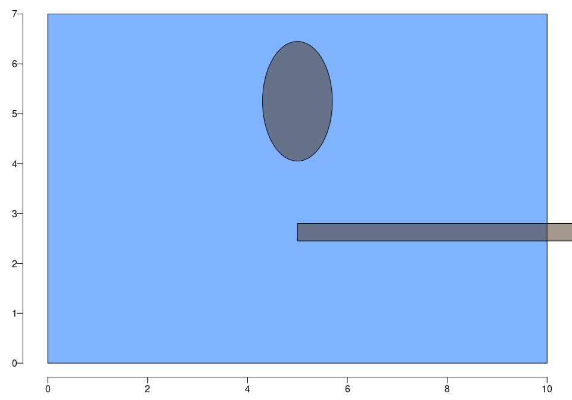

```r
par(mar = c(2, 2, 0, 0), mgp = c(2, 0.5, 0), las=1)
plot(t(bb), bty="n", type = "n", asp = 1)
polygon(domain, col = rgb(0.5,0.7,1))
polygon(barrier1, col = rgb(0.3,0.2,0.1, 0.5))
polygon(barrier2, col = rgb(0.3,0.2,0.1, 0.5))
```

The problem is to model data in both sides of the barrier considering that the correlation between then should account for the barrier. The proposed method in Bakka et al. (2019) models the entire domain, including the barrier. To deal with the barrier, the correlation range is set to be reasonable shorter over the barrier domain than the one at the domain of interest. This idea is simple and does not add any parameter in the usual stationary model. Furthermore, it can be implemented with any inferential method.

In Bakka et al. (2019), the proposed method consider the Stochastic Partial Differential Equations - SPDE approach proposed in Lindgren, Rue, and Lindström (2011). The implementation illustrated in [this tutorial](https://haakonbakkagit.github.io/btopic128.html) deals with a discretization of the domain. The discretization should be considered with some care. The fraction fixed for the analysis interplay with the width of the barrier. One should choose a small enough fraction, see details in Bakka et al. (2019).

We first load the packages that will be used in this tutorial.

```r
library(INLA)
```

```r
library(INLAspacetime)
library(inlabru)
library(ggplot2)
library(patchwork)
```

# Model definition and discretization

Let us consider that there is an underlying random field over the specified domain. This random field will be discretized using the mesh so that a precision matrix is defined for the distribution at the mesh nodes. We will define the barrier model as proposed in Bakka et al. (2019) which make use of a triangulation.

# Mesh and triangles

The solution consider a discretization of the spatial domain and the simplest one is using triangles. Therefore we start with the following mesh made up of small triangles in the domain and bigger around it.

```r
mesh <- inla.mesh.2d(
    loc.domain = domain,
    max.edge = c(0.2, 0.5),
    offset = c(0.3, 2),
    cutoff = 0.1)
mesh$n
```

```
#> [1] 6074
```

The solution needs the triangles inside the barrier domain to be identified. We start computing the center of each mesh triangle with

```r
triCenters <-
    cbind(
        mesh$loc[mesh$graph$tv[,1], 1] +
        mesh$loc[mesh$graph$tv[,2], 1] +
        mesh$loc[mesh$graph$tv[,3], 1],
        mesh$loc[mesh$graph$tv[,1], 2] +
        mesh$loc[mesh$graph$tv[,2], 2] +
        mesh$loc[mesh$graph$tv[,3], 2])/3
```

For each triangle center we check if it is inside or not of the barrier domain and and create a vector to identify to which domain is each triangle center inside

```r
isInBarrier <- (splancs::inout(triCenters, barrier1)) |
  (splancs::inout(triCenters, barrier2))
```

We can visualize the mesh and color the triangle centers using the **ggplot** methods from the **inlabru** package

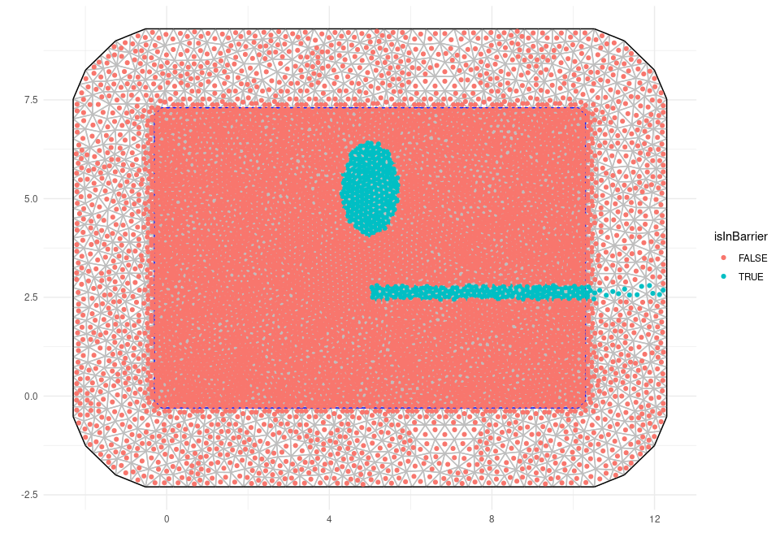

```r
ggplot() +
    gg(mesh) +
    geom_point(aes(
        x = triCenters[,1],
        y = triCenters[,2],
        color = isInBarrier)) +
  theme_minimal() + xlab("") + ylab("")
```

Notice that the mesh goes beyond the domain area including a boundary extension. Then we also had defined the barrier so that it is also defined in this boundary. Therefore, when building the model over this discretization, the barrier will be well defined and the behavior of the process will be as intended.

## Precision matrix

The parameters in this model are the range and the marginal variance, We also define the range parameter in the barrier so that the method works. We consider the range for the barrier as a fraction of the range over the domain. We just use half of the average rectangle edges as the range in the domain and 10% of it in the barrier.

```r
sigma <- 1
(ranges <- r * c(0.5, 0.05))
```

```
#> [1] 4.250 0.425
```

We will implement the model with the mesh previously defined. This start with defining which triangles have centers in the barrier.

```r
triBarrier <- which(isInBarrier)
length(triBarrier)
```

```
#> [1] 582
```

Then we compute the Finite Element matrices needed for the model discretization, as detailed in Bakka et al. (2019).

```r
bfem <- mesh2fem.barrier(mesh, triBarrier)
```

We now build the precision matrix with

```r
Q <- inla.barrier.q(bfem, ranges = ranges, sigma = sigma)
```

## Correlation

We can use the discretized model to compute correlation between pairs of points in order to check the properties of the model. Let us define a function that computes the correlation from a given set of location to each mesh node location.

```r
localCorrel <- function(locs, mesh, Q) {
  nl <- nrow(locs)
  ii <- sapply(1:nl, function(i)
    which.min(rowSums(sweep(
      mesh$loc[, 1:ncol(locs)], 2, locs[i, ], "-")^2)))
  b <- matrix(0, nrow(Q), nl)
  for(i in 1:nl)
    b[ii[i], i] <- 1
  cc <- inla.qsolve(Q, b)
  s <- sqrt(diag(inla.qinv(Q)))
  for(i in 1:nl)
    cc[, i] <- cc[, i] / (s * s[ii[i]])
  return(drop(cc))
}
```

Consider a set of locations and compute the correlations with

```r
locs <- cbind(c(0.3, 0.7, 0.7, 0.3) * rxy[1],
              c(0.7, 0.7, 0.3, 0.3) * rxy[2])
mcorrels <- localCorrel(locs, mesh, Q)
dim(mcorrels)
```

```
#> [1] 6074    4
```

We have the correlation from each mesh node to each of the specified locations. We would like to visualize it as an image so that we have these correlation from the location to “everywhere”. Let us build a projector to project any vector from the mesh nodes to a fine grid and projected with

```r
pgrid <- inla.mesh.projector(
    mesh,
    xlim = bb[1, ],
    ylim = bb[2, ],
    dims = round(500 * rxy/r))
gcorrels <- as.matrix(inla.mesh.project(
  pgrid, field = mcorrels
))
```

We can now create a `data.frame` with the expanded coordinates of the pixels

```r
grid.df <- data.frame(
  x = rep(pgrid$x, times = length(pgrid$y)),
  y = rep(pgrid$y, each = length(pgrid$x)))
```

The correlations can be projected and prepared for plotting with

```r
ggcorrels <- do.call(
  rbind,
  lapply(1:4, function(l)
    data.frame(grid.df,
               loc = paste(sprintf("%1.1f", locs[l, 1]),
                           sprintf("%1.1f", locs[l, 2]), sep = ", "),
               correlation = gcorrels[, l])))
```

In order to help the visualization of correlations, we will dropped the pixels with small correlations, less than $0.1$. We can now visualize the images with

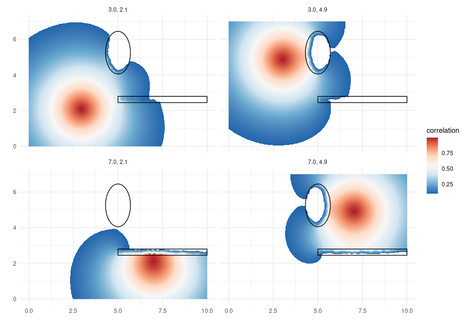

```r
ggplot() +
  geom_raster(
    data = ggcorrels[ggcorrels$correlation>0.1, ],
    mapping = aes(x = x, y = y, fill = correlation)) +
  facet_wrap(~ loc) +
  add.b0 + gg.add ## look to the appendix for the code for this
```

Notice that the model is also defined in the barrier domain. Therefore we can do computations at the barrier. We visualized the correlation over the barriers as well, and added the barrier borders, so that we can see the action of the short spatial range over the barriers. This visual inspection helps to verify if the short range over the barrier domain was set small enough.

# Data simulation

We consider that the random field is observed with noise. We first sample from the random field distribution.

## A random field sample

There are several algorithms to sample from a random field specified over a continuous domain without barriers. We will use the already defined precision matrix to draw a sample at the mesh nodes with

```r
u <- inla.qsample(1, Q, seed = 1)[,1]
```

These values sampled at the mesh nodes can be projected to a set of small pixels for visualization purpose with

```r
ugrid.sim <- inla.mesh.project(pgrid, field = u)
```

We can now visualize the projected simulated values at the small pixels, inclusive those values in the barriers.

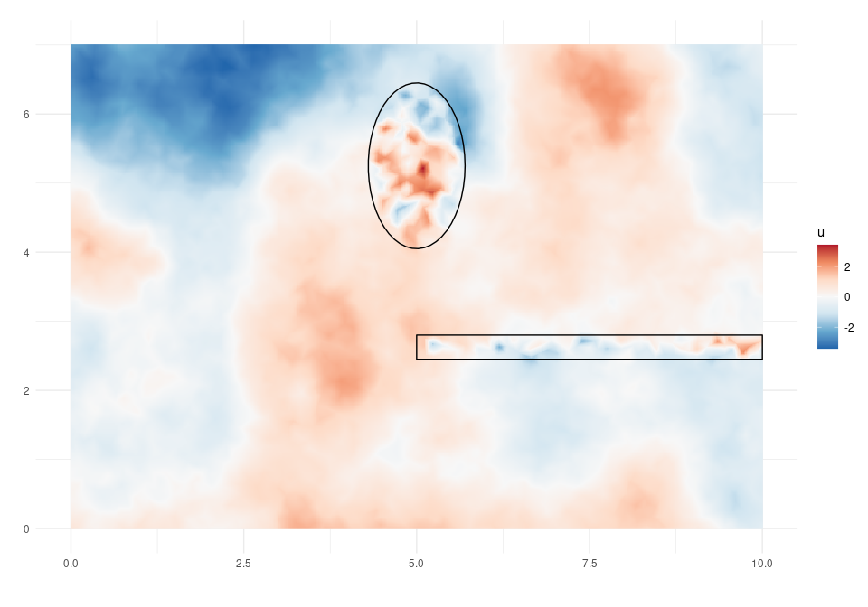

```r
grid.df$u <- as.vector(ugrid.sim)
ggplot() +
  geom_raster(
    data = grid.df,
    aes(x = x, y = y, fill = u)) +
  add.b0 + gg.add ## look to the appendix for the code for this
```

The visualization of the simulated process over the barrier allows a visual inspection of the model property. The process in different sides of the barriers seen to be independent, as illustrated by the correlation plots.

## Sampling a set of observations

We define a initial set of locations to consider that we observe the field at these locations. We start with a set of locations chosen completely at random in the rectangle domain, including a barrier part

```r
n0 <- 300
set.seed(2)
xy0 <- cbind(
  runif(n0, bb[1, 1], bb[1, 2]),
  runif(n0, bb[2, 1], bb[2, 2]))
```

Then we check which of these is inside the barrier

```r
xy.b <- (splancs::inout(xy0, barrier1)) |
  (splancs::inout(xy0, barrier2))
ii <- which(!xy.b)
```

The locations to form the data consider only the locations in the desired domain and outside the barrier

```r
dataset <- data.frame(
  x = xy0[ii, 1], y = xy0[ii, 2])
(n <- nrow(dataset))
```

```
#> [1] 280
```

To simulate the outcome, we project the field to these locations, add an intercept and some random noise

```r
sigma.e <- 1
set.seed(3)
dataset$outcome <-
    drop(inla.mesh.project(
        mesh,
        loc = cbind(dataset$x, dataset$y),
        field = u)) +
  10 + rnorm(n, 0.0, sigma.e)
```